# Eksplorasi dan Identifikasi Lag

## Identifikasi Lag

### Plot ACF

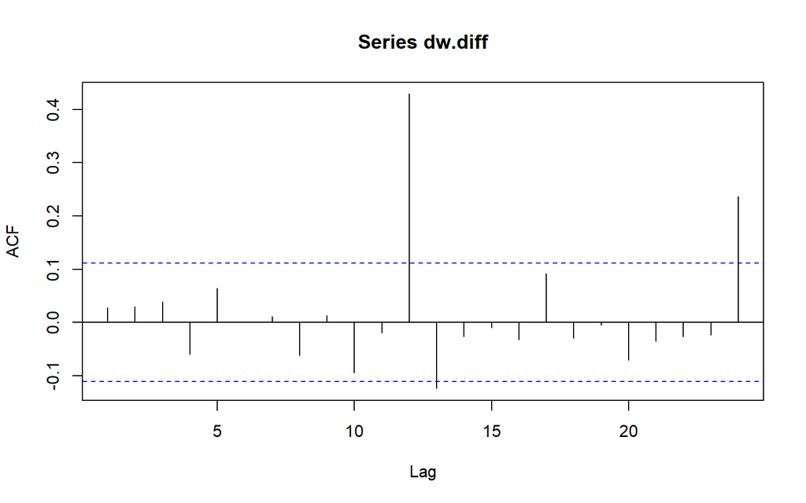

```r
acf(dw.diff)
```

Berdasarkan plot tersebut, terlihat bahwa plot ACF cenderung cut off di lag ke-12.

### Plot PACF

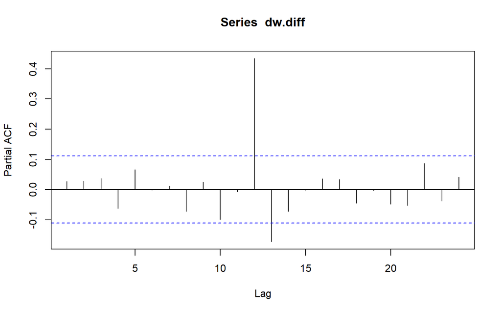

```r
pacf(dw.diff)
```

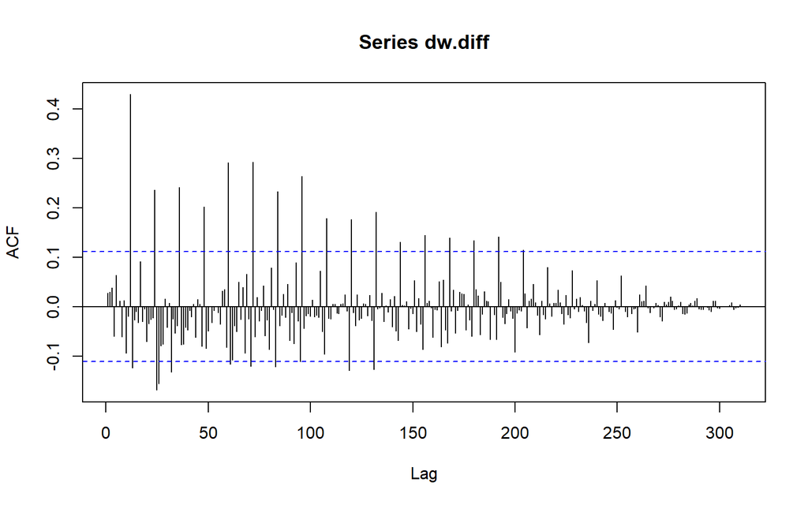

```r
acf(dw.diff, lag.max = length(di.shift) - 1)
```

Berdasarkan plot tersebut, terlihat bahwa plot PACF cenderung cut off di lag ke-12, sejalan dengan hasil eksplorasi plot deret waktu yang menunjukkan adanya pola musiman setiap 12 bulan sekali.

### Efek Musiman

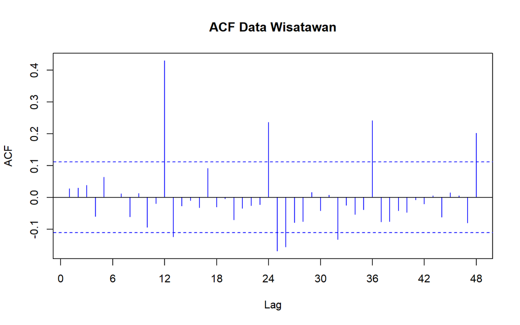

```r
acf0 <- acf(dw.diff, main = "ACF Data Wisatawan", lag.max = 48, xaxt = "n", col = "blue")
axis(1, at = seq(0, 48, by = 6), labels = seq(0, 48, by = 6))
```

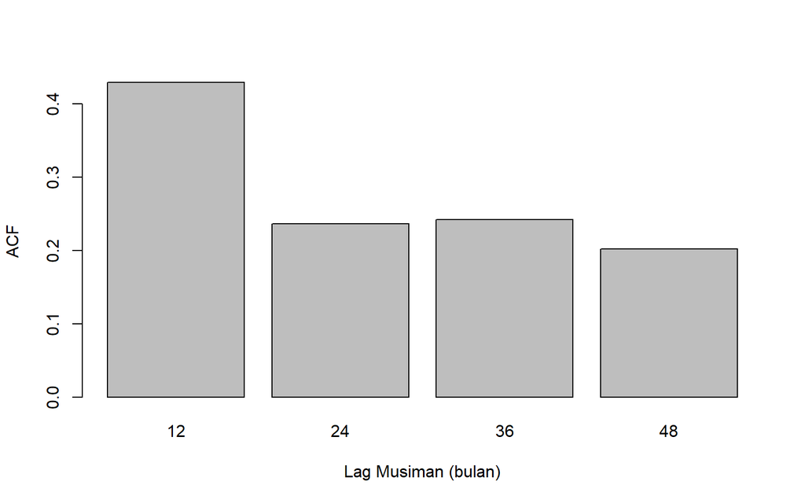

```r
acf_df <- data.frame(acf = as.numeric(acf0$acf), lag = as.numeric(acf0$lag))
acf_seasonal <- acf_df[acf_df$lag %% 12 == 0 & acf_df$lag != 0, ]
barplot(height = acf_seasonal$acf, names.arg = acf_seasonal$lag, ylab = "ACF", xlab = "Lag Musiman (bulan)")
```

# VAR

```r
ts_var <- cbind(
  dk.diff, di.shift, dw.diff
)

ts_var <- na.omit(ts_var)
```

```r
lag_selection <- VARselect(
  ts_var,
  lag.max = 12,
  type = "const"
)

lag_selection
```

```
## $selection
## AIC(n)  HQ(n)  SC(n) FPE(n)
##     12      1      1     12
##
## $criteria
##                   1            2            3            4            5
## AIC(n) 1.685900e+01 1.683417e+01 1.685559e+01 1.688978e+01 1.690942e+01
## HQ(n)  1.691844e+01 1.693819e+01 1.700419e+01 1.708297e+01 1.714719e+01
## SC(n)  1.700751e+01 1.709407e+01 1.722687e+01 1.737245e+01 1.750347e+01
## FPE(n) 2.097840e+07 2.046434e+07 2.090838e+07 2.163773e+07 2.206999e+07
##                   6            7            8            9           10
## AIC(n) 1.692208e+01 1.695044e+01 1.698099e+01 1.703009e+01 1.704701e+01
## HQ(n)  1.720442e+01 1.727737e+01 1.735250e+01 1.744618e+01 1.750768e+01
## SC(n)  1.762751e+01 1.776726e+01 1.790920e+01 1.806968e+01 1.819798e+01
## FPE(n) 2.235565e+07 2.300535e+07 2.372798e+07 2.493392e+07 2.537445e+07
##                  11           12
## AIC(n) 1.704659e+01 1.681077e+01
## HQ(n)  1.755184e+01 1.736061e+01
## SC(n)  1.830895e+01 1.818452e+01
## FPE(n) 2.538208e+07 2.006722e+07
```

Berdasarkan informasi nilai HQ dan SC, lag dominan pada ketiga peubah terjadi pada lag ke-1

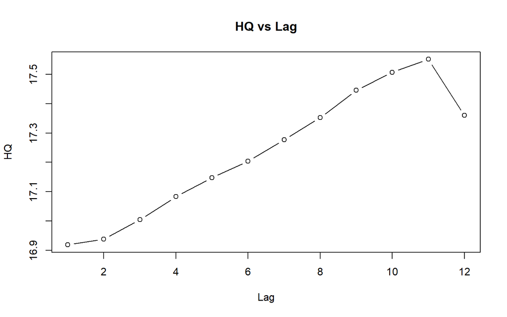

```r
plot(lag_selection$criteria["HQ(n)",], type="b",
     xlab="Lag", ylab="HQ", main="HQ vs Lag")
```

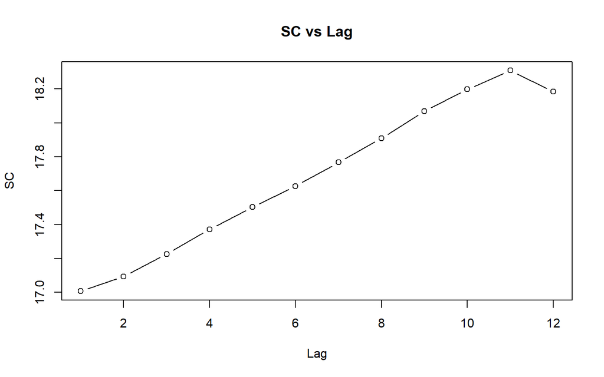

```r
plot(lag_selection$criteria["SC(n)",], type="b",
     xlab="Lag", ylab="SC", main="SC vs Lag")
```